# Qualifying standards for World Maters Championships 2019

Marianne, Friedrich, David, Les

07 October 2018

# 1 Trend in participation in IWF world championships across years

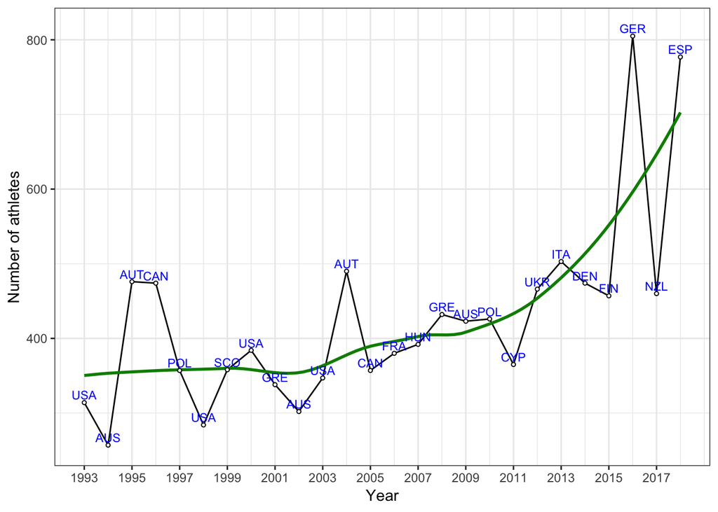

The number of participants has been steadily increasing over the years with an explosion of the number of participants in recent years. It is expected that this explosion will continue.

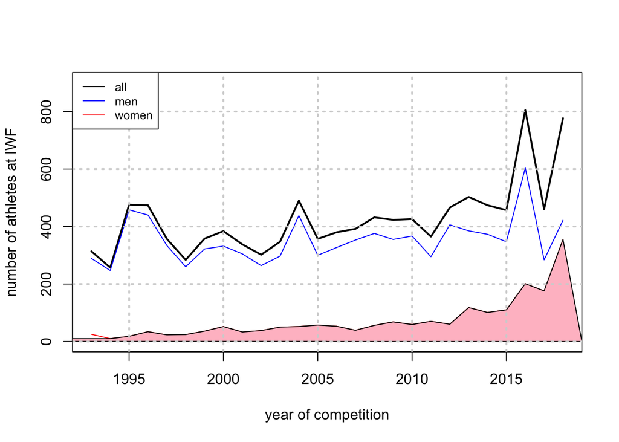

The increase in women participation has been seen in US National competitions for a while. Among the younger age groups women outnumbered men at the IWF 2018 in Barcelona.

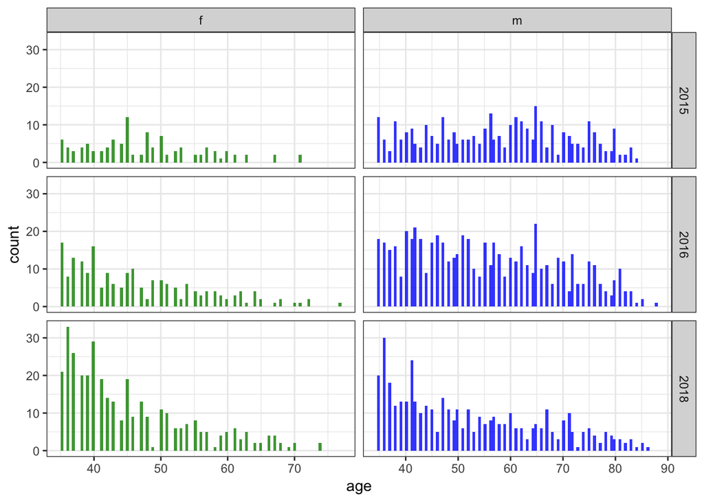

Trend in number of participants

# 2 Bodyweight distribution

The middle weight classes have the largest number of lifters.

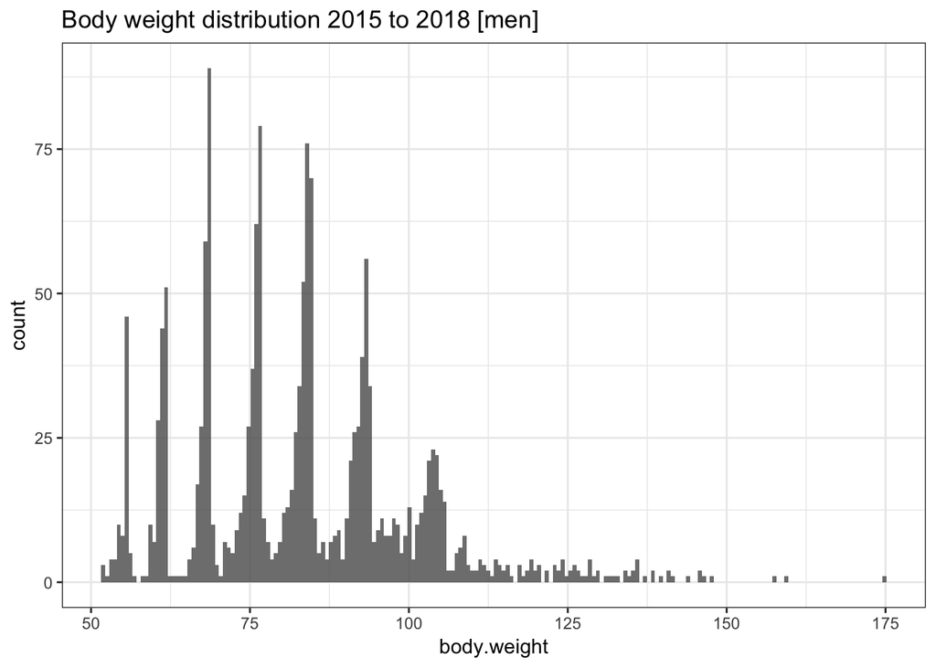

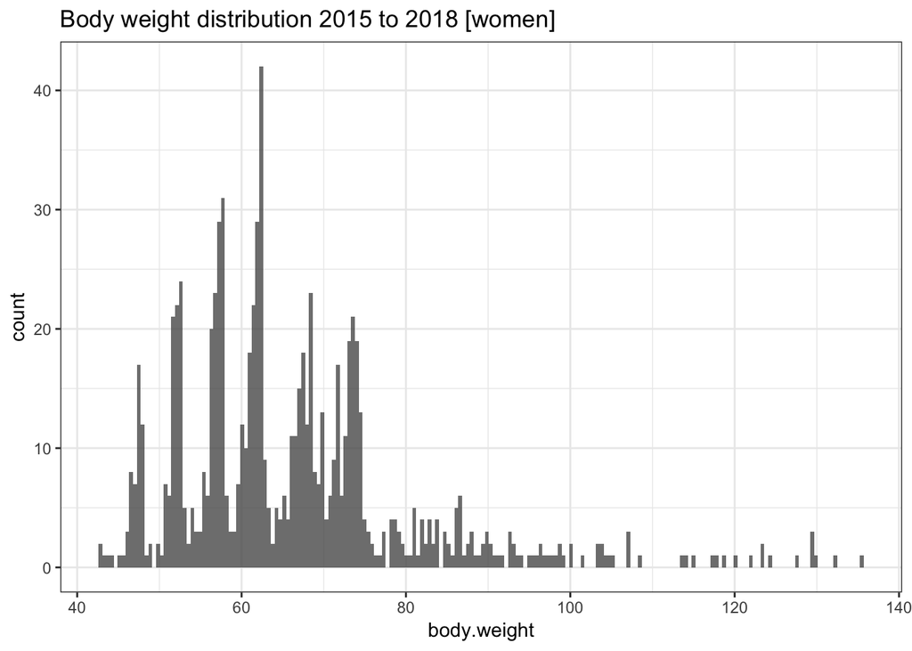

Due the body weight and age distributions it is reasonable to calculate qualifying totals [in kg] based on SMF cutoff values calculated for the top body weight in each weight class and an age in the middle of each age class (e.g. 37, 42, etc)

A decision needed to be made to choose a reference weight for the heaviest weight classes. In this document the reference weight was chosen to be 116 kg for men and 103 kg for women. The median (1st, 3rd quartile) are 103 (95,117) kg for women and 116 (109, 127) kg for men.

## 2.1 Number of participants

This indicates that the most pressure is in the younger age groups in the middle body weight categories.

For ease of viewing all numbers larger than 10 are in red.

### 2.1.1 IWF 2015 in Rovaniemi, Finland

| M35 | M40 | M45 | M50 | M55 | M60 | M65 | M70 | M75 | M80 | weightcat |
| --- | --- | --- | --- | --- | --- | --- | --- | --- | --- | --- |
| 0 | 1 | 0 | 1 | 3 | 3 | 1 | 2 | 2 | 0 | 56 |
| 1 | 3 | 5 | 3 | 4 | 6 | 4 | 3 | 3 | 2 | 62 |
| 4 | 4 | 7 | 5 | 4 | 5 | 8 | 4 | 4 | 4 | 69 |
| 5 | 3 | 6 | 6 | 9 | 12 | 10 | 6 | 6 | 4 | 77 |
| 11 | 8 | 6 | 5 | 7 | 7 | 2 | 5 | 5 | 2 | 85 |
| 8 | 6 | 2 | 3 | 5 | 6 | 10 | 6 | 6 | 4 | 94 |
| 3 | 6 | 10 | 4 | 5 | 5 | 5 | 2 | 2 | 2 | 105 |
| 6 | 5 | 2 | 2 | 2 | 4 | 2 | 1 | 1 | 0 | 105+ |

| W35 | W40 | W45 | W50 | W55 | W60 | W65 | W70 | W75 | W80 | weightcat |
| --- | --- | --- | --- | --- | --- | --- | --- | --- | --- | --- |
| 2 | 0 | 2 | 1 | 1 | 0 | 0 | 0 | 0 | 0 | 48 |
| 4 | 1 | 2 | 2 | 2 | 3 | 0 | 1 | 1 | 0 | 53 |
| 4 | 3 | 1 | 3 | 3 | 0 | 0 | 0 | 0 | 0 | 58 |
| 3 | 4 | 5 | 3 | 2 | 1 | 1 | 1 | 1 | 0 | 63 |
| 3 | 2 | 5 | 3 | 1 | 1 | 0 | 0 | 0 | 0 | 69 |
| 4 | 5 | 6 | 2 | 1 | 1 | 0 | 0 | 0 | 0 | 75 |
| 1 | 4 | 3 | 1 | 1 | 1 | 1 | 0 | 0 | 0 | 90 |
| 1 | 2 | 4 | 1 | 1 | 0 | 0 | 0 | 0 | 0 | 90+ |

### 2.1.2 IWF 2016 in Heinsheim, Germany

| M35 | M40 | M45 | M50 | M55 | M60 | M65 | M70 | M75 | M80 | weightcat |
| --- | --- | --- | --- | --- | --- | --- | --- | --- | --- | --- |
| 2 | 4 | 2 | 1 | 3 | 4 | 6 | 1 | 1 | 1 | 56 |
| 6 | 5 | 3 | 4 | 8 | 7 | 6 | 3 | 3 | 4 | 62 |
| 5 | 7 | 8 | 11 | 10 | 5 | 9 | 9 | 9 | 3 | 69 |
| 7 | 15 | 11 | 10 | 9 | 9 | 14 | 7 | 7 | 9 | 77 |
| 23 | 23 | 20 | 13 | 10 | 13 | 7 | 8 | 8 | 4 | 85 |
| 15 | 16 | 16 | 10 | 8 | 12 | 12 | 6 | 6 | 4 | 94 |
| 10 | 5 | 13 | 13 | 13 | 6 | 5 | 5 | 5 | 3 | 105 |
| 6 | 11 | 5 | 7 | 6 | 5 | 3 | 3 | 3 | 1 | 105+ |

| W35 | W40 | W45 | W50 | W55 | W60 | W65 | W70 | W75 | W80 | weightcat |
| --- | --- | --- | --- | --- | --- | --- | --- | --- | --- | --- |
| 7 | 3 | 1 | 1 | 1 | 1 | 0 | 0 | 0 | 0 | 48 |
| 5 | 6 | 2 | 2 | 2 | 3 | 1 | 2 | 2 | 0 | 53 |
| 11 | 8 | 6 | 4 | 3 | 3 | 1 | 0 | 0 | 0 | 58 |
| 10 | 6 | 6 | 6 | 3 | 2 | 1 | 2 | 2 | 0 | 63 |
| 11 | 5 | 4 | 4 | 2 | 1 | 1 | 0 | 0 | 0 | 69 |
| 11 | 7 | 7 | 6 | 2 | 3 | 0 | 0 | 0 | 0 | 75 |
| 2 | 3 | 2 | 1 | 5 | 1 | 1 | 0 | 0 | 0 | 90 |
| 2 | 3 | 5 | 2 | 0 | 0 | 0 | 0 | 0 | 0 | 90+ |

### 2.1.3 IWF 2018 in Barcelona, Spain

| M35 | M40 | M45 | M50 | M55 | M60 | M65 | M70 | M75 | M80 | weightcat |
| --- | --- | --- | --- | --- | --- | --- | --- | --- | --- | --- |
| 2 | 4 | 3 | 2 | 2 | 2 | 3 | 3 | 3 | 0 | 56 |
| 2 | 5 | 4 | 3 | 4 | 4 | 3 | 3 | 3 | 2 | 62 |
| 15 | 11 | 2 | 4 | 7 | 5 | 4 | 6 | 6 | 3 | 69 |
| 15 | 14 | 10 | 5 | 8 | 5 | 5 | 6 | 6 | 3 | 77 |
| 28 | 11 | 12 | 10 | 5 | 4 | 6 | 4 | 4 | 2 | 85 |
| 13 | 13 | 6 | 5 | 5 | 4 | 3 | 4 | 4 | 2 | 94 |
| 10 | 9 | 9 | 6 | 2 | 2 | 6 | 2 | 2 | 2 | 105 |
| 8 | 5 | 3 | 7 | 5 | 5 | 2 | 1 | 1 | 1 | 105+ |

| W35 | W40 | W45 | W50 | W55 | W60 | W65 | W70 | W75 | W80 | weightcat |
| --- | --- | --- | --- | --- | --- | --- | --- | --- | --- | --- |
| 4 | 9 | 2 | 2 | 2 | 2 | 1 | 0 | 0 | 0 | 48 |
| 7 | 7 | 6 | 6 | 2 | 3 | 3 | 0 | 0 | 0 | 53 |
| 24 | 10 | 8 | 3 | 2 | 4 | 4 | 2 | 2 | 0 | 58 |
| 24 | 19 | 7 | 12 | 5 | 4 | 3 | 0 | 0 | 0 | 63 |
| 21 | 11 | 10 | 5 | 2 | 1 | 1 | 1 | 1 | 0 | 69 |
| 22 | 18 | 9 | 6 | 4 | 4 | 1 | 1 | 1 | 0 | 75 |
| 11 | 5 | 7 | 5 | 5 | 1 | 0 | 0 | 0 | 0 | 90 |
| 7 | 4 | 2 | 1 | 1 | 2 | 0 | 0 | 0 | 0 | 90+ |

# 3 SMF cutoffs, qualifying totals, and number of participants

*Comment: A Poisson regression model to predict the number of lifters in each age/weight category showed that of the three predictors age, weight, and SMF, only the age group plays a statistically significant role. That means there are more lifters in the younger age groups. The larger numbers of the middle body weight classes seen in the younger age groups are too few cells, so that body weight did not reach statistical significance to predict the number of lifters. Thus is would be acceptable to focus on qualifying standards by age category only.*

## 3.1 Current World Championships qualifying SMF

From the current qualifying total standards corresponding SMF were calculated and listed below for each age/weight combinations. This calculation is needed to compare the SMF cutoff scenario suggested by the Advisory Committee.

World championships current qualifying SMF [women]

|  | W35 | W40 | W45 | W50 | W55 | W60 | W65 | W70 | W75 | W80+ |
| --- | --- | --- | --- | --- | --- | --- | --- | --- | --- | --- |
| 48 | 142 | 147 | 141 | 140 | 137 | 137 | 138 | 142 | 164 | 197 |
| 53 | 145 | 145 | 140 | 139 | 137 | 131 | 133 | 138 | 159 | 191 |
| 58 | 144 | 144 | 140 | 136 | 133 | 134 | 132 | 135 | 156 | 187 |
| 63 | 144 | 145 | 137 | 133 | 132 | 134 | 130 | 136 | 157 | 188 |
| 69 | 139 | 140 | 138 | 134 | 134 | 131 | 130 | 136 | 157 | 188 |
| 75 | 140 | 138 | 135 | 133 | 132 | 131 | 128 | 135 | 156 | 187 |
| 90 | 135 | 134 | 132 | 131 | 130 | 124 | 125 | 131 | 152 | 182 |
| 90+ | 137 | 136 | 133 | 132 | 130 | 124 | 123 | 130 | 150 | 180 |

World championships current qualifying SMF [men]

|  | M35 | M40 | M45 | M50 | M55 | M60 | M65 | M70 | M75 | M80+ |
| --- | --- | --- | --- | --- | --- | --- | --- | --- | --- | --- |
| 56 | 260 | 262 | 264 | 262 | 253 | 252 | 245 | 224 | 231 | 228 |
| 62 | 268 | 268 | 272 | 266 | 260 | 261 | 252 | 228 | 241 | 212 |
| 69 | 272 | 273 | 279 | 275 | 267 | 265 | 259 | 234 | 246 | 216 |
| 77 | 276 | 278 | 285 | 279 | 273 | 268 | 260 | 236 | 245 | 219 |
| 85 | 280 | 283 | 285 | 281 | 276 | 274 | 262 | 237 | 254 | 225 |
| 94 | 283 | 284 | 287 | 284 | 277 | 276 | 266 | 237 | 248 | 221 |
| 105 | 283 | 285 | 285 | 283 | 277 | 273 | 265 | 238 | 251 | 227 |
| 105+ | 284 | 285 | 289 | 285 | 277 | 277 | 267 | 242 | 255 | 229 |

## 3.2 Comparisons of scenarios for SMF cutpoints

The median SMF for each age class of the current world championships SMF qualifying standards was taken to arrive at a SMF qualifying standard currently used at the worlds.

SMF cutpoints [men]

| agecat | M35 | M40 | M45 | M50 | M55 | M60 | M65 | M70 | M75 | M80+ |
| --- | --- | --- | --- | --- | --- | --- | --- | --- | --- | --- |
| world | 278 | 280 | 285 | 280 | 274 | 270 | 261 | 236 | 247 | 223 |
| AC | 290 | 290 | 285 | 280 | 275 | 270 | 265 | 260 | 255 | 250 |

SMF cutpoints [women]

| agecat | W35 | W40 | W45 | W50 | W55 | W60 | W65 | W70 |
| --- | --- | --- | --- | --- | --- | --- | --- | --- |
| world | 141 | 142 | 138 | 134 | 132 | 131 | 130 | 136 |
| AC | 170 | 170 | 160 | 155 | 150 | 145 | 140 | 136 |

*The SMF standard for men was proposed in order to stay close to the current standard, but increase for the younger age groups due to the large number of participants. The standards were raised a small amount in the older age groups for consistency ages 65 and up.*

*The proposed SMF standard for women accounts for the exploding participation of women, especially in the younger age groups. The current standard for women is unusually low. Thus the choice for the younger age groups was driven by the number of participants, and then linearly decreased for older ages.*

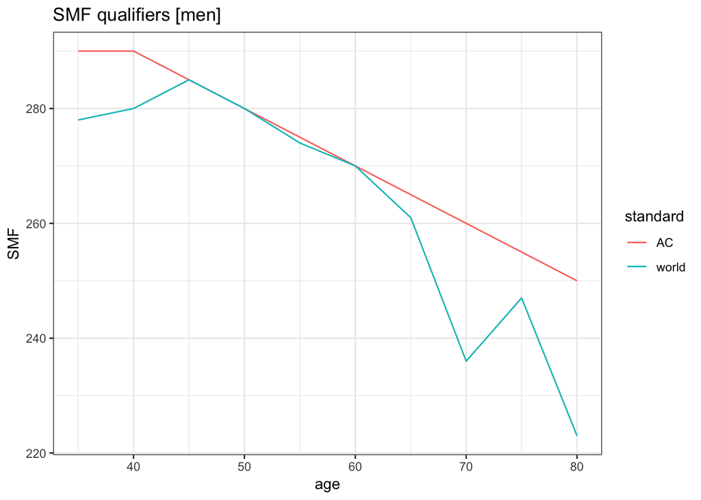

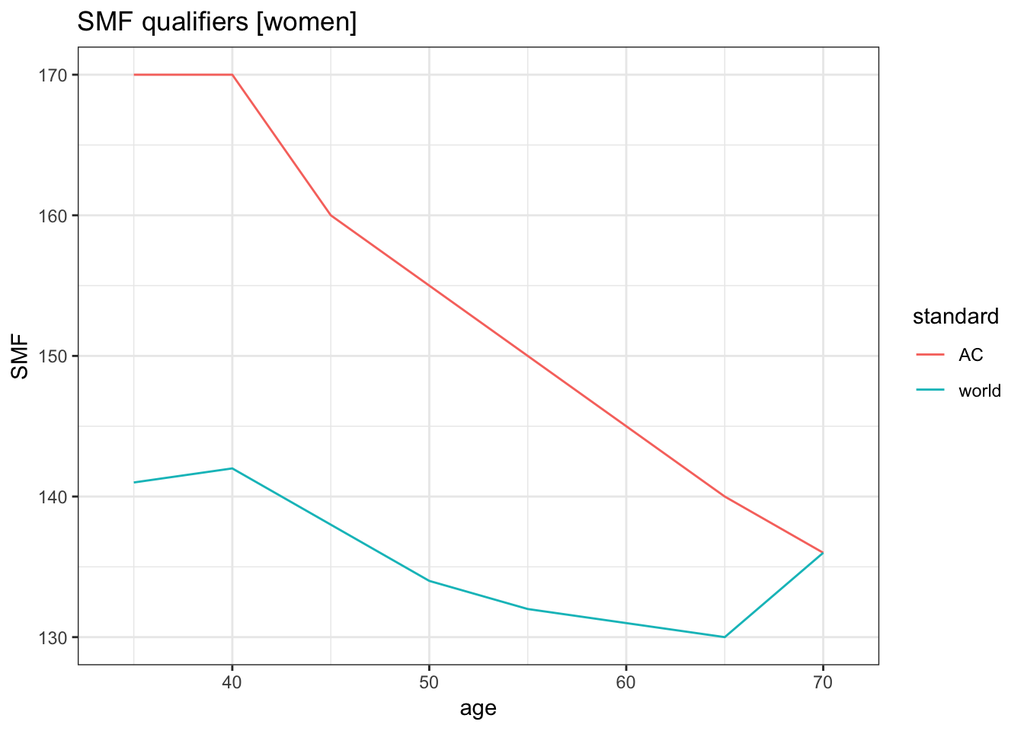

# 4 Number of qualifying athletes

In the following the number of qualifying athletes are calculated according to different schemes of qualifying totals based on the proposed SMF standard However the number appears lower, since 5 to 8% of the participants did not total.

When determining targets for registration limits, the following points need to be considered.

1. *Registration limit:* About 8 to 16% of athletes who register are not able to participate. Thus a target of 700 participants at the world championships could mean a target of 756 to 812 participants for registrations. This could also be differentiated for gender. There tend to be fewer no-shows for women than for men.
2. *SMF/QT standards:* The proportion of athletes who do not total are 5 to 8%. These are not included in the numbers below, even though they may qualify with the new qualifying standards. Thus when deciding on a heme that should result in 700 athletes, for example, it would be advisable to choose a target of 644 to 665 athletes

## 4.1 Number of Lifters satisfying the qualifying standards

### 4.1.1 Number of Lifters satisfying the proposed qualifying standards by the Advisory Committee according the old weight categories

Below are the number of lifters who reached or exceeded the qualifying totals. It does not take into account lifters who were within the 10/15 kg rule.

Approximately 10% of lifters do not reach the CURRENT qualifying totals at the world masters championships.

In the table below “num.lift”= number of liftes with a total >0, “num.Wqual” =number of lifters whose competition results exceeded the current QT standard, “num.ACqual”= number of lifters whose competition results exceeded the QT standard proposed by the Advisory Committee.

Number of lifters exceeding the QT [men]

| year | agecat | num.lift | num.Wqual | num.ACqual | pct.ACqual |
| --- | --- | --- | --- | --- | --- |
| 2015 | M35 | 36 | 33 | 29 | 80.6 |
| 2015 | M40 | 32 | 31 | 25 | 78.1 |
| 2015 | M45 | 33 | 29 | 29 | 87.9 |
| 2015 | M50 | 27 | 23 | 23 | 85.2 |
| 2015 | M55 | 35 | 31 | 31 | 88.6 |
| 2015 | M60 | 45 | 41 | 41 | 91.1 |
| 2015 | M65 | 38 | 36 | 36 | 94.7 |
| 2015 | M70 | 26 | 25 | 20 | 76.9 |
| 2015 | M75 | 30 | 29 | 29 | 96.7 |
| 2015 | M80+ | 18 | 17 | 15 | 83.3 |
| 2016 | M35 | 70 | 61 | 45 | 64.3 |
| 2016 | M40 | 78 | 66 | 55 | 70.5 |
| 2016 | M45 | 71 | 65 | 65 | 91.5 |
| 2016 | M50 | 62 | 52 | 52 | 83.9 |
| 2016 | M55 | 63 | 53 | 53 | 84.1 |
| 2016 | M60 | 53 | 48 | 48 | 90.6 |
| 2016 | M65 | 58 | 54 | 53 | 91.4 |
| 2016 | M70 | 37 | 34 | 32 | 86.5 |
| 2016 | M75 | 34 | 30 | 30 | 88.2 |
| 2016 | M80+ | 26 | 24 | 20 | 76.9 |
| 2018 | M35 | 86 | 74 | 61 | 70.9 |
| 2018 | M40 | 67 | 58 | 47 | 70.1 |
| 2018 | M45 | 43 | 38 | 38 | 88.4 |
| 2018 | M50 | 39 | 32 | 32 | 82.1 |
| 2018 | M55 | 37 | 28 | 28 | 75.7 |
| 2018 | M60 | 29 | 26 | 26 | 89.7 |
| 2018 | M65 | 30 | 29 | 28 | 93.3 |
| 2018 | M70 | 29 | 28 | 24 | 82.8 |
| 2018 | M75 | 20 | 19 | 17 | 85.0 |
| 2018 | M80+ | 15 | 13 | 13 | 86.7 |

Number of lifters exceeding the QT [women]

| year | agecat | num.lift | num.Wqual | num.ACqual | pct.ACqual |
| --- | --- | --- | --- | --- | --- |
| 2015 | W35 | 18 | 18 | 11 | 61.1 |
| 2015 | W40 | 21 | 18 | 10 | 47.6 |
| 2015 | W45 | 24 | 21 | 16 | 66.7 |
| 2015 | W50 | 16 | 15 | 13 | 81.2 |
| 2015 | W55 | 12 | 11 | 8 | 66.7 |
| 2015 | W60 | 7 | 6 | 5 | 71.4 |
| 2015 | W65 | 2 | 2 | 2 | 100.0 |
| 2015 | W70 | 2 | 2 | 2 | 100.0 |
| 2016 | W35 | 56 | 54 | 32 | 57.1 |
| 2016 | W40 | 40 | 37 | 24 | 60.0 |
| 2016 | W45 | 32 | 29 | 25 | 78.1 |
| 2016 | W50 | 26 | 25 | 20 | 76.9 |
| 2016 | W55 | 17 | 14 | 7 | 41.2 |
| 2016 | W60 | 12 | 12 | 10 | 83.3 |
| 2016 | W65 | 5 | 5 | 4 | 80.0 |
| 2016 | W70 | 4 | 4 | 4 | 100.0 |
| 2018 | W35 | 111 | 107 | 74 | 66.7 |
| 2018 | W40 | 79 | 79 | 65 | 82.3 |
| 2018 | W45 | 48 | 48 | 37 | 77.1 |
| 2018 | W50 | 38 | 38 | 32 | 84.2 |
| 2018 | W55 | 23 | 21 | 16 | 69.6 |
| 2018 | W60 | 21 | 19 | 16 | 76.2 |
| 2018 | W65 | 13 | 13 | 12 | 92.3 |
| 2018 | W70 | 4 | 4 | 4 | 100.0 |

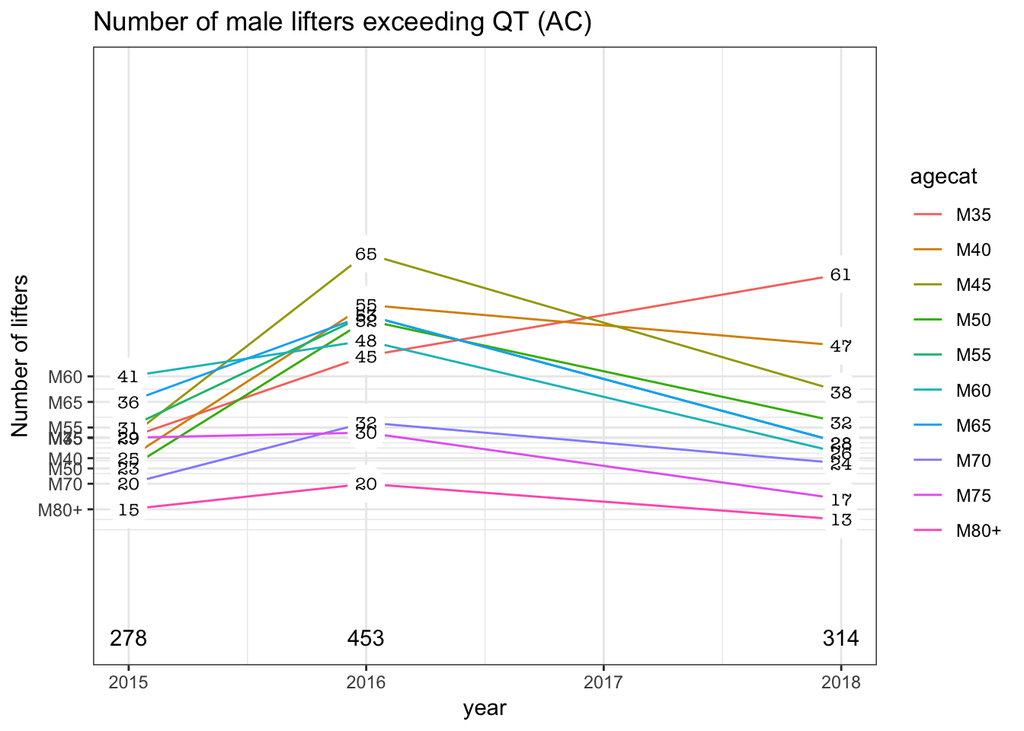

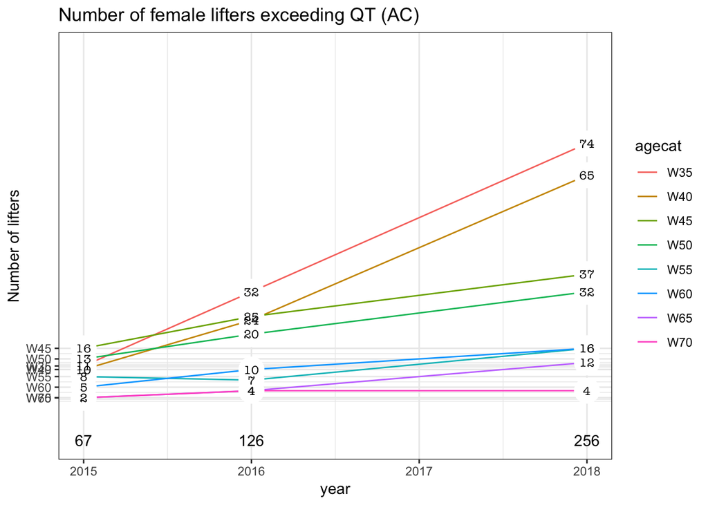

**At the IWF 2016 (GER) there were 552 men with a total and 192 women with a total.**

**At the IWF 2018 (ESP) there were 395 men with a total and 337 women with a total.**

With the proposed qualifying standards the estimated number of future participants is 453 men (2016 data) and 256 women (2018 data) for a total of 709 weightlifters. Since this is based on those with a total >0, an estimated total number is **766** participants.  
However, it can be assumed that the number of qualfied athletes continues to rise especially in the 35-44 age group.

### 4.1.2 Corresponding numbers using the current norm

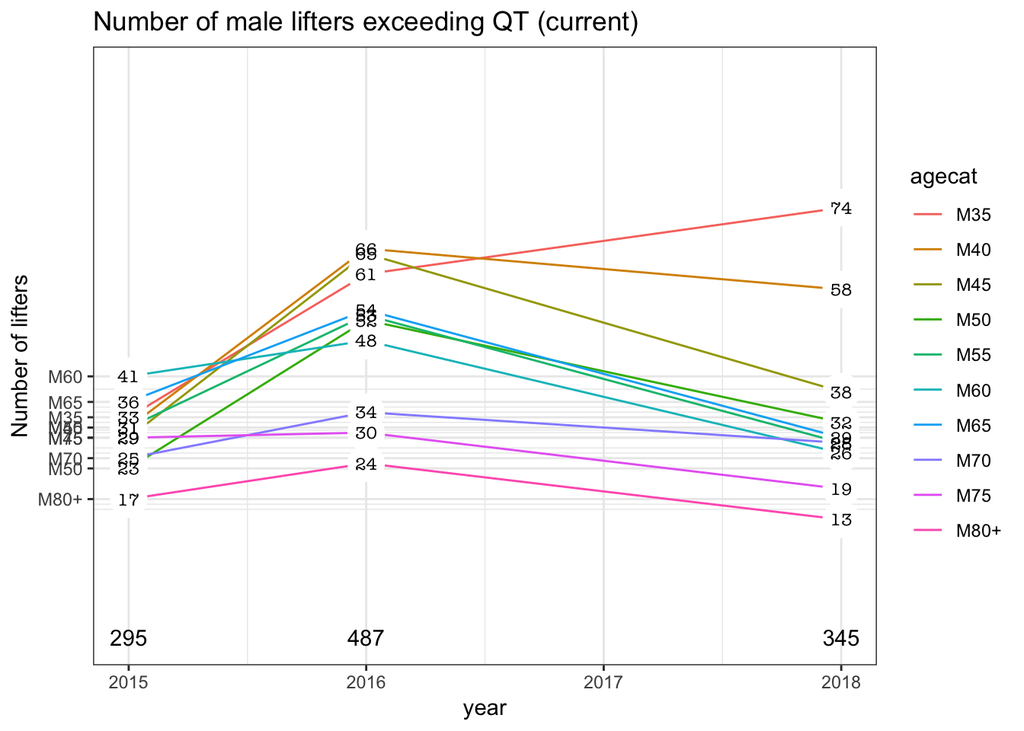

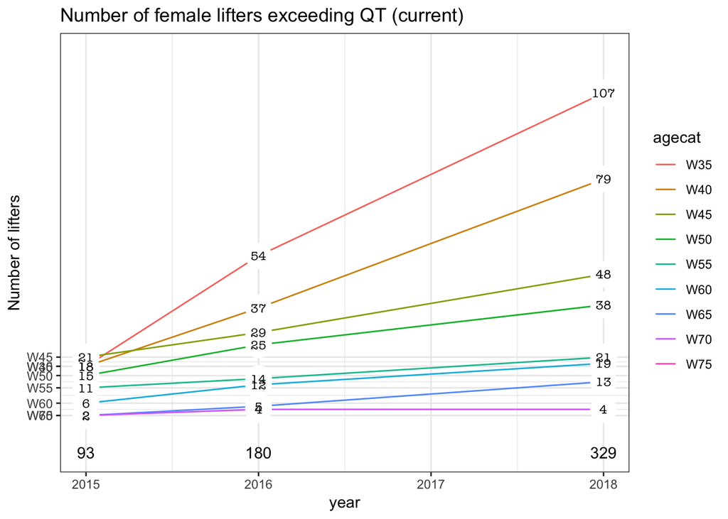

## 4.2 Number of qualifying athletes by age and weight class for the proposed qualifying standards based on IWF 2018 (Spain)

This is based on the actual performances of the athletes at the world masters championship. Thus it does not count athletes who had a total of zero. Also note that between 10 and 30% of the lifters in age groups 35-44, 45-59, and 60+ may have had a total below the qualifying total. It is possible that the “0” number of qualifying participant for certain age/weight combinations did not have participants to begin with.

Number of men qualifying

| agecombine | wtcat | num.lift | smf0 | world.tot | world.num | smf3 | AC.tot | AC.num |
| --- | --- | --- | --- | --- | --- | --- | --- | --- |
| M35 | 56 | 2 | 278 | 166 | 1 | 290 | 173 | 0 |
| M35 | 62 | 2 | 278 | 178 | 2 | 290 | 186 | 2 |
| M35 | 69 | 15 | 278 | 191 | 12 | 290 | 199 | 10 |
| M35 | 77 | 15 | 278 | 203 | 12 | 290 | 212 | 10 |
| M35 | 85 | 28 | 278 | 214 | 22 | 290 | 223 | 17 |
| M35 | 94 | 13 | 278 | 223 | 11 | 290 | 233 | 9 |
| M35 | 105 | 10 | 278 | 233 | 7 | 290 | 243 | 7 |
| M35 | 105+ | 8 | 278 | 240 | 7 | 290 | 250 | 6 |
| M40 | 56 | 4 | 280 | 157 | 2 | 290 | 163 | 2 |
| M40 | 62 | 5 | 280 | 169 | 3 | 290 | 175 | 3 |
| M40 | 69 | 11 | 280 | 181 | 7 | 290 | 188 | 5 |
| M40 | 77 | 14 | 280 | 193 | 11 | 290 | 200 | 9 |
| M40 | 85 | 11 | 280 | 203 | 10 | 290 | 210 | 8 |
| M40 | 94 | 13 | 280 | 212 | 12 | 290 | 220 | 9 |
| M40 | 105 | 9 | 280 | 221 | 9 | 290 | 229 | 7 |
| M40 | 105+ | 5 | 280 | 228 | 4 | 290 | 236 | 4 |
| M45 | 56 | 3 | 285 | 151 | 1 | 285 | 151 | 1 |
| M45 | 62 | 4 | 285 | 162 | 3 | 285 | 162 | 3 |
| M45 | 69 | 2 | 285 | 174 | 0 | 285 | 174 | 0 |
| M45 | 77 | 10 | 285 | 185 | 9 | 285 | 185 | 9 |
| M45 | 85 | 12 | 285 | 195 | 10 | 285 | 195 | 10 |
| M45 | 94 | 6 | 285 | 203 | 5 | 285 | 203 | 5 |
| M45 | 105 | 9 | 285 | 212 | 7 | 285 | 212 | 7 |
| M45 | 105+ | 3 | 285 | 219 | 3 | 285 | 219 | 3 |
| M50 | 56 | 2 | 280 | 139 | 1 | 280 | 139 | 1 |
| M50 | 62 | 3 | 280 | 149 | 2 | 280 | 149 | 2 |
| M50 | 69 | 4 | 280 | 160 | 3 | 280 | 160 | 3 |
| M50 | 77 | 5 | 280 | 170 | 4 | 280 | 170 | 4 |
| M50 | 85 | 10 | 280 | 179 | 7 | 280 | 179 | 7 |
| M50 | 94 | 5 | 280 | 187 | 5 | 280 | 187 | 5 |
| M50 | 105 | 6 | 280 | 195 | 5 | 280 | 195 | 5 |
| M50 | 105+ | 7 | 280 | 201 | 5 | 280 | 201 | 5 |
| M55 | 56 | 2 | 274 | 125 | 1 | 275 | 125 | 1 |
| M55 | 62 | 4 | 274 | 134 | 3 | 275 | 134 | 3 |
| M55 | 69 | 7 | 274 | 143 | 6 | 275 | 144 | 6 |
| M55 | 77 | 8 | 274 | 153 | 6 | 275 | 153 | 6 |
| M55 | 85 | 5 | 274 | 161 | 3 | 275 | 161 | 3 |
| M55 | 94 | 5 | 274 | 168 | 5 | 275 | 169 | 5 |
| M55 | 105 | 2 | 274 | 175 | 1 | 275 | 176 | 1 |
| M55 | 105+ | 5 | 274 | 180 | 3 | 275 | 181 | 3 |
| M60 | 56 | 2 | 270 | 112 | 2 | 270 | 112 | 2 |
| M60 | 62 | 4 | 270 | 121 | 3 | 270 | 121 | 3 |
| M60 | 69 | 5 | 270 | 130 | 4 | 270 | 130 | 4 |
| M60 | 77 | 5 | 270 | 138 | 3 | 270 | 138 | 3 |
| M60 | 85 | 4 | 270 | 145 | 4 | 270 | 145 | 4 |
| M60 | 94 | 4 | 270 | 152 | 4 | 270 | 152 | 4 |
| M60 | 105 | 2 | 270 | 158 | 2 | 270 | 158 | 2 |
| M60 | 105+ | 5 | 270 | 163 | 4 | 270 | 163 | 4 |
| M65 | 56 | 3 | 261 | 98 | 3 | 265 | 100 | 3 |
| M65 | 62 | 3 | 261 | 105 | 3 | 265 | 107 | 3 |
| M65 | 69 | 4 | 261 | 113 | 4 | 265 | 115 | 3 |
| M65 | 77 | 5 | 261 | 120 | 3 | 265 | 122 | 3 |
| M65 | 85 | 6 | 261 | 127 | 6 | 265 | 128 | 6 |
| M65 | 94 | 3 | 261 | 132 | 2 | 265 | 134 | 2 |
| M65 | 105 | 6 | 261 | 138 | 6 | 265 | 140 | 6 |
| M65 | 105+ | 2 | 261 | 142 | 2 | 265 | 144 | 2 |
| M70 | 56 | 3 | 236 | 79 | 3 | 260 | 87 | 3 |
| M70 | 62 | 3 | 236 | 85 | 3 | 260 | 93 | 2 |
| M70 | 69 | 6 | 236 | 91 | 5 | 260 | 100 | 4 |
| M70 | 77 | 6 | 236 | 97 | 6 | 260 | 107 | 4 |
| M70 | 85 | 4 | 236 | 102 | 4 | 260 | 112 | 4 |
| M70 | 94 | 4 | 236 | 106 | 4 | 260 | 117 | 4 |
| M70 | 105 | 2 | 236 | 111 | 2 | 260 | 122 | 2 |
| M70 | 105+ | 1 | 236 | 114 | 1 | 260 | 126 | 1 |
| M75 | 56 | 2 | 247 | 72 | 1 | 255 | 74 | 1 |
| M75 | 62 | 2 | 247 | 77 | 2 | 255 | 79 | 2 |
| M75 | 69 | 2 | 247 | 82 | 2 | 255 | 85 | 2 |
| M75 | 77 | 2 | 247 | 88 | 2 | 255 | 91 | 2 |
| M75 | 85 | 6 | 247 | 92 | 5 | 255 | 95 | 5 |
| M75 | 94 | 2 | 247 | 96 | 2 | 255 | 100 | 1 |
| M75 | 105 | 4 | 247 | 100 | 4 | 255 | 104 | 3 |
| M75 | 105+ | 1 | 247 | 104 | 1 | 255 | 107 | 1 |
| M80+ | 56 | NA | 223 | 54 | 0 | 250 | 60 | 0 |
| M80+ | 62 | 2 | 223 | 58 | 2 | 250 | 65 | 2 |
| M80+ | 69 | 3 | 223 | 62 | 3 | 250 | 70 | 3 |
| M80+ | 77 | 3 | 223 | 66 | 3 | 250 | 74 | 3 |
| M80+ | 85 | 2 | 223 | 69 | 2 | 250 | 78 | 2 |
| M80+ | 94 | 2 | 223 | 73 | 1 | 250 | 81 | 1 |
| M80+ | 105 | 2 | 223 | 76 | 1 | 250 | 85 | 1 |
| M80+ | 105+ | 1 | 223 | 78 | 1 | 250 | 87 | 1 |

Number of women qualifying

| agecombine | wtcat | num.lift | smf0 | world.tot | world.num | smf3 | AC.tot | AC.num |
| --- | --- | --- | --- | --- | --- | --- | --- | --- |
| W35 | 48 | 4 | 141 | 81 | 3 | 170 | 98 | 2 |
| W35 | 53 | 7 | 141 | 87 | 6 | 170 | 105 | 5 |
| W35 | 58 | 24 | 141 | 93 | 22 | 170 | 112 | 16 |
| W35 | 63 | 24 | 141 | 98 | 21 | 170 | 118 | 16 |
| W35 | 69 | 21 | 141 | 103 | 19 | 170 | 125 | 12 |
| W35 | 75 | 22 | 141 | 108 | 21 | 170 | 130 | 14 |
| W35 | 90 | 11 | 141 | 117 | 8 | 170 | 141 | 5 |
| W35 | 90+ | 7 | 141 | 122 | 7 | 170 | 147 | 4 |
| W40 | 48 | 9 | 142 | 77 | 9 | 170 | 92 | 9 |
| W40 | 53 | 7 | 142 | 83 | 7 | 170 | 99 | 7 |
| W40 | 58 | 10 | 142 | 88 | 10 | 170 | 106 | 8 |
| W40 | 63 | 19 | 142 | 93 | 17 | 170 | 112 | 14 |
| W40 | 69 | 11 | 142 | 98 | 10 | 170 | 118 | 7 |
| W40 | 75 | 18 | 142 | 103 | 17 | 170 | 123 | 13 |
| W40 | 90 | 5 | 142 | 111 | 5 | 170 | 133 | 4 |
| W40 | 90+ | 4 | 142 | 116 | 4 | 170 | 139 | 3 |
| W45 | 48 | 2 | 138 | 71 | 2 | 160 | 82 | 2 |
| W45 | 53 | 6 | 138 | 76 | 6 | 160 | 88 | 4 |
| W45 | 58 | 8 | 138 | 81 | 8 | 160 | 94 | 6 |
| W45 | 63 | 7 | 138 | 85 | 7 | 160 | 99 | 6 |
| W45 | 69 | 10 | 138 | 90 | 9 | 160 | 104 | 9 |
| W45 | 75 | 9 | 138 | 94 | 9 | 160 | 109 | 6 |
| W45 | 90 | 7 | 138 | 102 | 6 | 160 | 118 | 3 |
| W45 | 90+ | 2 | 138 | 106 | 1 | 160 | 123 | 1 |
| W50 | 48 | 2 | 134 | 64 | 2 | 155 | 74 | 2 |
| W50 | 53 | 6 | 134 | 69 | 6 | 155 | 80 | 5 |
| W50 | 58 | 3 | 134 | 74 | 3 | 155 | 85 | 3 |
| W50 | 63 | 12 | 134 | 78 | 11 | 155 | 90 | 9 |
| W50 | 69 | 5 | 134 | 82 | 5 | 155 | 95 | 4 |
| W50 | 75 | 6 | 134 | 85 | 5 | 155 | 99 | 3 |
| W50 | 90 | 5 | 134 | 92 | 5 | 155 | 107 | 5 |
| W50 | 90+ | 1 | 134 | 96 | 1 | 155 | 112 | 1 |
| W55 | 48 | 2 | 132 | 58 | 2 | 150 | 66 | 2 |
| W55 | 53 | 2 | 132 | 63 | 2 | 150 | 71 | 2 |
| W55 | 58 | 2 | 132 | 67 | 2 | 150 | 76 | 1 |
| W55 | 63 | 5 | 132 | 70 | 5 | 150 | 80 | 4 |
| W55 | 69 | 2 | 132 | 74 | 1 | 150 | 84 | 1 |
| W55 | 75 | 4 | 132 | 77 | 4 | 150 | 88 | 4 |
| W55 | 90 | 5 | 132 | 83 | 4 | 150 | 95 | 1 |
| W55 | 90+ | 1 | 132 | 87 | 1 | 150 | 99 | 1 |
| W60 | 48 | 2 | 131 | 53 | 2 | 145 | 58 | 2 |
| W60 | 53 | 3 | 131 | 57 | 3 | 145 | 63 | 2 |
| W60 | 58 | 4 | 131 | 60 | 4 | 145 | 67 | 4 |
| W60 | 63 | 4 | 131 | 64 | 4 | 145 | 71 | 4 |
| W60 | 69 | 1 | 131 | 67 | 1 | 145 | 74 | 1 |
| W60 | 75 | 4 | 131 | 70 | 4 | 145 | 78 | 2 |
| W60 | 90 | 1 | 131 | 76 | 0 | 145 | 84 | 0 |
| W60 | 90+ | 2 | 131 | 79 | 1 | 145 | 88 | 1 |
| W65 | 48 | 1 | 130 | 47 | 1 | 140 | 51 | 1 |
| W65 | 53 | 3 | 130 | 51 | 3 | 140 | 55 | 3 |
| W65 | 58 | 4 | 130 | 54 | 4 | 140 | 58 | 3 |
| W65 | 63 | 3 | 130 | 57 | 3 | 140 | 61 | 3 |
| W65 | 69 | 1 | 130 | 60 | 1 | 140 | 65 | 1 |
| W65 | 75 | 1 | 130 | 63 | 1 | 140 | 68 | 1 |
| W65 | 90 | NA | 130 | 68 | 0 | 140 | 73 | 0 |
| W65 | 90+ | NA | 130 | 71 | 0 | 140 | 76 | 0 |
| W70 | 48 | NA | 136 | 44 | 0 | 136 | 44 | 0 |
| W70 | 53 | NA | 136 | 47 | 0 | 136 | 47 | 0 |
| W70 | 58 | 2 | 136 | 50 | 2 | 136 | 50 | 2 |
| W70 | 63 | NA | 136 | 53 | 0 | 136 | 53 | 0 |
| W70 | 69 | 1 | 136 | 56 | 1 | 136 | 56 | 1 |
| W70 | 75 | 1 | 136 | 58 | 1 | 136 | 58 | 1 |
| W70 | 90 | NA | 136 | 63 | 0 | 136 | 63 | 0 |
| W70 | 90+ | NA | 136 | 66 | 0 | 136 | 66 | 0 |
| W75 | 48 | NA | 136 | 38 | 0 | 136 | 38 | 0 |
| W75 | 53 | NA | 136 | 41 | 0 | 136 | 41 | 0 |
| W75 | 58 | NA | 136 | 44 | 0 | 136 | 44 | 0 |
| W75 | 63 | NA | 136 | 46 | 0 | 136 | 46 | 0 |
| W75 | 69 | NA | 136 | 48 | 0 | 136 | 48 | 0 |
| W75 | 75 | NA | 136 | 51 | 0 | 136 | 51 | 0 |
| W75 | 90 | NA | 136 | 55 | 0 | 136 | 55 | 0 |
| W75 | 90+ | NA | 136 | 57 | 0 | 136 | 57 | 0 |
| W80+ | 48 | NA | 136 | 32 | 0 | 136 | 32 | 0 |
| W80+ | 53 | NA | 136 | 34 | 0 | 136 | 34 | 0 |
| W80+ | 58 | NA | 136 | 36 | 0 | 136 | 36 | 0 |
| W80+ | 63 | NA | 136 | 38 | 0 | 136 | 38 | 0 |
| W80+ | 69 | NA | 136 | 40 | 0 | 136 | 40 | 0 |
| W80+ | 75 | NA | 136 | 42 | 0 | 136 | 42 | 0 |
| W80+ | 90 | NA | 136 | 46 | 0 | 136 | 46 | 0 |
| W80+ | 90+ | NA | 136 | 48 | 0 | 136 | 48 | 0 |

## 4.3 Number of qualifying athletes by age and weight class for the proposed qualifying standards based on IWF 2016 (Germany)

Number of men qualifying

| agecombine | wtcat | num.lift | smf0 | world.tot | world.num | smf3 | AC.tot | AC.num |
| --- | --- | --- | --- | --- | --- | --- | --- | --- |
| M35 | 56 | 2 | 278 | 166 | 2 | 290 | 173 | 1 |
| M35 | 62 | 6 | 278 | 178 | 3 | 290 | 186 | 1 |
| M35 | 69 | 5 | 278 | 191 | 4 | 290 | 199 | 4 |
| M35 | 77 | 7 | 278 | 203 | 6 | 290 | 212 | 6 |
| M35 | 85 | 23 | 278 | 214 | 19 | 290 | 223 | 13 |
| M35 | 94 | 15 | 278 | 223 | 14 | 290 | 233 | 9 |
| M35 | 105 | 10 | 278 | 233 | 8 | 290 | 243 | 6 |
| M35 | 105+ | 6 | 278 | 240 | 5 | 290 | 250 | 5 |
| M40 | 56 | 4 | 280 | 157 | 1 | 290 | 163 | 1 |
| M40 | 62 | 5 | 280 | 169 | 4 | 290 | 175 | 3 |
| M40 | 69 | 7 | 280 | 181 | 3 | 290 | 188 | 3 |
| M40 | 77 | 15 | 280 | 193 | 13 | 290 | 200 | 11 |
| M40 | 85 | 23 | 280 | 203 | 19 | 290 | 210 | 16 |
| M40 | 94 | 16 | 280 | 212 | 12 | 290 | 220 | 10 |
| M40 | 105 | 5 | 280 | 221 | 5 | 290 | 229 | 4 |
| M40 | 105+ | 11 | 280 | 228 | 9 | 290 | 236 | 7 |
| M45 | 56 | 2 | 285 | 151 | 1 | 285 | 151 | 1 |
| M45 | 62 | 3 | 285 | 162 | 3 | 285 | 162 | 3 |
| M45 | 69 | 8 | 285 | 174 | 7 | 285 | 174 | 7 |
| M45 | 77 | 11 | 285 | 185 | 8 | 285 | 185 | 8 |
| M45 | 85 | 20 | 285 | 195 | 15 | 285 | 195 | 15 |
| M45 | 94 | 16 | 285 | 203 | 13 | 285 | 203 | 13 |
| M45 | 105 | 13 | 285 | 212 | 13 | 285 | 212 | 13 |
| M45 | 105+ | 5 | 285 | 219 | 5 | 285 | 219 | 5 |
| M50 | 56 | 1 | 280 | 139 | 0 | 280 | 139 | 0 |
| M50 | 62 | 4 | 280 | 149 | 3 | 280 | 149 | 3 |
| M50 | 69 | 11 | 280 | 160 | 6 | 280 | 160 | 6 |
| M50 | 77 | 10 | 280 | 170 | 7 | 280 | 170 | 7 |
| M50 | 85 | 13 | 280 | 179 | 9 | 280 | 179 | 9 |
| M50 | 94 | 10 | 280 | 187 | 9 | 280 | 187 | 9 |
| M50 | 105 | 13 | 280 | 195 | 11 | 280 | 195 | 11 |
| M50 | 105+ | 7 | 280 | 201 | 7 | 280 | 201 | 7 |
| M55 | 56 | 3 | 274 | 125 | 1 | 275 | 125 | 1 |
| M55 | 62 | 8 | 274 | 134 | 8 | 275 | 134 | 8 |
| M55 | 69 | 10 | 274 | 143 | 8 | 275 | 144 | 8 |
| M55 | 77 | 9 | 274 | 153 | 7 | 275 | 153 | 7 |
| M55 | 85 | 10 | 274 | 161 | 8 | 275 | 161 | 8 |
| M55 | 94 | 8 | 274 | 168 | 7 | 275 | 169 | 7 |
| M55 | 105 | 13 | 274 | 175 | 9 | 275 | 176 | 9 |
| M55 | 105+ | 6 | 274 | 180 | 5 | 275 | 181 | 5 |
| M60 | 56 | 4 | 270 | 112 | 4 | 270 | 112 | 4 |
| M60 | 62 | 7 | 270 | 121 | 6 | 270 | 121 | 6 |
| M60 | 69 | 5 | 270 | 130 | 4 | 270 | 130 | 4 |
| M60 | 77 | 9 | 270 | 138 | 8 | 270 | 138 | 8 |
| M60 | 85 | 13 | 270 | 145 | 11 | 270 | 145 | 11 |
| M60 | 94 | 12 | 270 | 152 | 9 | 270 | 152 | 9 |
| M60 | 105 | 6 | 270 | 158 | 4 | 270 | 158 | 4 |
| M60 | 105+ | 5 | 270 | 163 | 2 | 270 | 163 | 2 |
| M65 | 56 | 6 | 261 | 98 | 5 | 265 | 100 | 5 |
| M65 | 62 | 6 | 261 | 105 | 6 | 265 | 107 | 6 |
| M65 | 69 | 9 | 261 | 113 | 9 | 265 | 115 | 8 |
| M65 | 77 | 14 | 261 | 120 | 12 | 265 | 122 | 12 |
| M65 | 85 | 7 | 261 | 127 | 5 | 265 | 128 | 5 |
| M65 | 94 | 12 | 261 | 132 | 10 | 265 | 134 | 10 |
| M65 | 105 | 5 | 261 | 138 | 4 | 265 | 140 | 4 |
| M65 | 105+ | 3 | 261 | 142 | 3 | 265 | 144 | 3 |
| M70 | 56 | 1 | 236 | 79 | 1 | 260 | 87 | 1 |
| M70 | 62 | 3 | 236 | 85 | 3 | 260 | 93 | 2 |
| M70 | 69 | 9 | 236 | 91 | 8 | 260 | 100 | 7 |
| M70 | 77 | 7 | 236 | 97 | 4 | 260 | 107 | 4 |
| M70 | 85 | 8 | 236 | 102 | 6 | 260 | 112 | 6 |
| M70 | 94 | 6 | 236 | 106 | 5 | 260 | 117 | 5 |
| M70 | 105 | 5 | 236 | 111 | 4 | 260 | 122 | 4 |
| M70 | 105+ | 3 | 236 | 114 | 3 | 260 | 126 | 3 |
| M75 | 56 | 1 | 247 | 72 | 0 | 255 | 74 | 0 |
| M75 | 62 | 6 | 247 | 77 | 6 | 255 | 79 | 6 |
| M75 | 69 | 6 | 247 | 82 | 6 | 255 | 85 | 6 |
| M75 | 77 | 5 | 247 | 88 | 5 | 255 | 91 | 5 |
| M75 | 85 | 9 | 247 | 92 | 6 | 255 | 95 | 6 |
| M75 | 94 | 3 | 247 | 96 | 2 | 255 | 100 | 2 |
| M75 | 105 | 4 | 247 | 100 | 3 | 255 | 104 | 3 |
| M75 | 105+ | 2 | 247 | 104 | 2 | 255 | 107 | 2 |
| M80+ | 56 | 1 | 223 | 54 | 1 | 250 | 60 | 1 |
| M80+ | 62 | 4 | 223 | 58 | 4 | 250 | 65 | 3 |
| M80+ | 69 | 3 | 223 | 62 | 3 | 250 | 70 | 2 |
| M80+ | 77 | 9 | 223 | 66 | 7 | 250 | 74 | 7 |
| M80+ | 85 | 4 | 223 | 69 | 3 | 250 | 78 | 3 |
| M80+ | 94 | 4 | 223 | 73 | 3 | 250 | 81 | 2 |
| M80+ | 105 | 3 | 223 | 76 | 3 | 250 | 85 | 2 |
| M80+ | 105+ | 1 | 223 | 78 | 0 | 250 | 87 | 0 |

# 5 Qualifying totals for the new weight categories

## 5.1 Proposed qualifying standards by the Advisory Committee for the new weight categories

Qualifying totals - new weight classes [men]

|  | M35 | M40 | M45 | M50 | M55 | M60 | M65 | M70 | M75 | M80+ |
| --- | --- | --- | --- | --- | --- | --- | --- | --- | --- | --- |
| 55 | 170 | 161 | 149 | 137 | 123 | 111 | 98 | 86 | 73 | 60 |
| 61 | 184 | 173 | 160 | 148 | 133 | 120 | 106 | 92 | 79 | 64 |
| 67 | 195 | 184 | 171 | 157 | 141 | 127 | 113 | 98 | 84 | 68 |
| 73 | 206 | 194 | 180 | 166 | 149 | 134 | 119 | 104 | 88 | 72 |
| 81 | 218 | 205 | 190 | 175 | 157 | 142 | 125 | 109 | 93 | 76 |
| 89 | 228 | 215 | 199 | 183 | 165 | 148 | 131 | 114 | 97 | 80 |
| 96 | 235 | 222 | 205 | 189 | 170 | 153 | 135 | 118 | 100 | 82 |
| 102 | 240 | 227 | 210 | 193 | 174 | 156 | 139 | 121 | 103 | 84 |
| 109 | 246 | 232 | 215 | 198 | 178 | 160 | 142 | 124 | 105 | 86 |
| 109+ | 250 | 236 | 219 | 201 | 181 | 163 | 144 | 126 | 107 | 87 |

Qualifying totals new weight classes [women]

|  | W35 | W40 | W45 | W50 | W55 | W60 | W65 | W70 |
| --- | --- | --- | --- | --- | --- | --- | --- | --- |
| 45 | 93 | 88 | 78 | 71 | 62 | 55 | 48 | 42 |
| 49 | 99 | 94 | 83 | 76 | 67 | 59 | 52 | 45 |
| 55 | 108 | 102 | 91 | 82 | 73 | 65 | 56 | 49 |
| 59 | 114 | 107 | 95 | 86 | 76 | 68 | 59 | 51 |
| 64 | 119 | 113 | 100 | 91 | 80 | 71 | 62 | 54 |
| 71 | 127 | 119 | 106 | 96 | 85 | 76 | 66 | 57 |
| 76 | 131 | 124 | 110 | 100 | 88 | 78 | 68 | 59 |
| 81 | 135 | 127 | 113 | 102 | 91 | 80 | 70 | 61 |
| 87 | 139 | 131 | 116 | 106 | 94 | 83 | 72 | 62 |
| 87+ | 147 | 139 | 123 | 112 | 99 | 88 | 76 | 66 |

## 5.2 Corresponding qualifying totals based on current standards for the new weight categories

Current qualifying totals [men]

|  | M35 | M40 | M45 | M50 | M55 | M60 | M65 | M70 | M75 | M80+ |
| --- | --- | --- | --- | --- | --- | --- | --- | --- | --- | --- |
| 55 | 163 | 155 | 149 | 137 | 123 | 111 | 97 | 78 | 71 | 53 |
| 61 | 176 | 167 | 160 | 148 | 132 | 120 | 104 | 84 | 76 | 57 |
| 67 | 187 | 178 | 171 | 157 | 141 | 127 | 111 | 89 | 81 | 61 |
| 73 | 197 | 187 | 180 | 166 | 148 | 134 | 117 | 94 | 85 | 64 |
| 81 | 209 | 198 | 190 | 175 | 157 | 142 | 124 | 99 | 90 | 68 |
| 89 | 218 | 207 | 199 | 183 | 164 | 148 | 129 | 104 | 94 | 71 |
| 96 | 225 | 214 | 205 | 189 | 169 | 153 | 133 | 107 | 97 | 73 |
| 102 | 230 | 219 | 210 | 193 | 173 | 156 | 136 | 110 | 99 | 75 |
| 109 | 235 | 224 | 215 | 198 | 177 | 160 | 139 | 112 | 102 | 77 |
| 109+ | 240 | 228 | 219 | 201 | 180 | 163 | 142 | 114 | 104 | 78 |

Current qualifying totals [women]

|  | W35 | W40 | W45 | W50 | W55 | W60 | W65 | W70 |
| --- | --- | --- | --- | --- | --- | --- | --- | --- |
| 45 | 77 | 73 | 67 | 61 | 55 | 50 | 45 | 42 |
| 49 | 82 | 78 | 72 | 65 | 59 | 54 | 48 | 45 |
| 55 | 90 | 85 | 78 | 71 | 64 | 58 | 52 | 49 |
| 59 | 94 | 89 | 82 | 75 | 67 | 61 | 55 | 51 |
| 64 | 99 | 94 | 86 | 78 | 71 | 64 | 58 | 54 |
| 71 | 105 | 100 | 91 | 83 | 75 | 68 | 61 | 57 |
| 76 | 109 | 103 | 95 | 86 | 78 | 71 | 63 | 59 |
| 81 | 112 | 106 | 97 | 89 | 80 | 73 | 65 | 61 |
| 87 | 115 | 109 | 100 | 91 | 82 | 75 | 67 | 62 |
| 87+ | 122 | 116 | 106 | 96 | 87 | 79 | 71 | 66 |